# Part II - (Fordgobike tripdata Explanatory Analysis )

### By (Emem Asuquo)

## Investigation Overview

Investigating the hours of rides and the age group of members,I used seaborn to plot a countplot to group the ages, then I used seaborn catplot to plot the hourly rides per user type and age group.  
I found that the adult age group(30 to 50 years) had the highest number of trips between 8am to 9am and 4pm to 6pm on weekdays for both customers and subscribers. The youth age group (19 to 30years) have the highest number of rides between 7pm and 11pm on weekdays for both customers and subscribers.

## Dataset Overview

The data contains information of 183,412 records of Fordgo bike trip in San Francisco. The dataset was made up of 16 columns and 183,412 rows. The columns are:

1. duration_sec
2. start_time
3. end_time
4. start_station_id
5. start_station_name
6. start_station_latitude
7. start_station_longitude
8. end_station_id
9. end_station_name
10. end_station_latitude
11. end_station_longitude
12. bike_id
13. user_type
14. member_birth_year
15. member_gender
16. bike_share_for_all_trip. The data set was downloaded from the udacity website for this project.

## Distribution of trip duration in minutes

The chart below shows the distribution of the main feature of interest which is the duration of the ride.

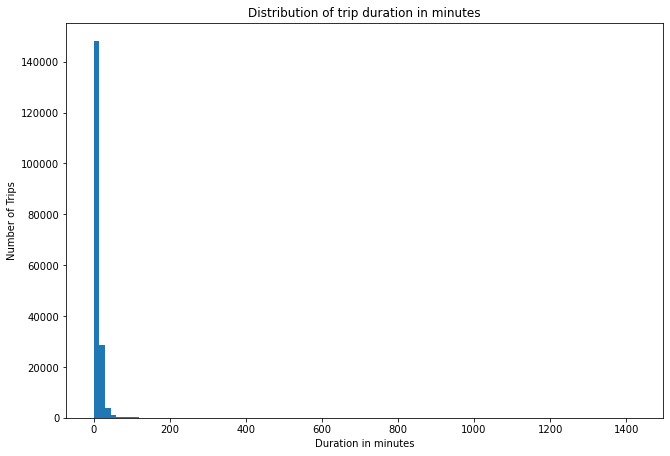

```python
# A histogram to show the bike trip duration in minutes
binsize = 15
bins = np.arange(0, bike_df1['duration_minutes'].max()+binsize, binsize)

plt.figure(figsize=[10.69, 7.27])
plt.hist(data = bike_df1, x = 'duration_minutes', bins=bins)
plt.title('Distribution of trip duration in minutes')
plt.xlabel('Duration in minutes')
plt.ylabel('Number of Trips')
plt.show()
```

From the chart above, it can be seen that the highest number of trips is between 0 to 200 minutes. The chart does not really show the distribution properly,I had to perform. a log transformation for a better view of the distribution.

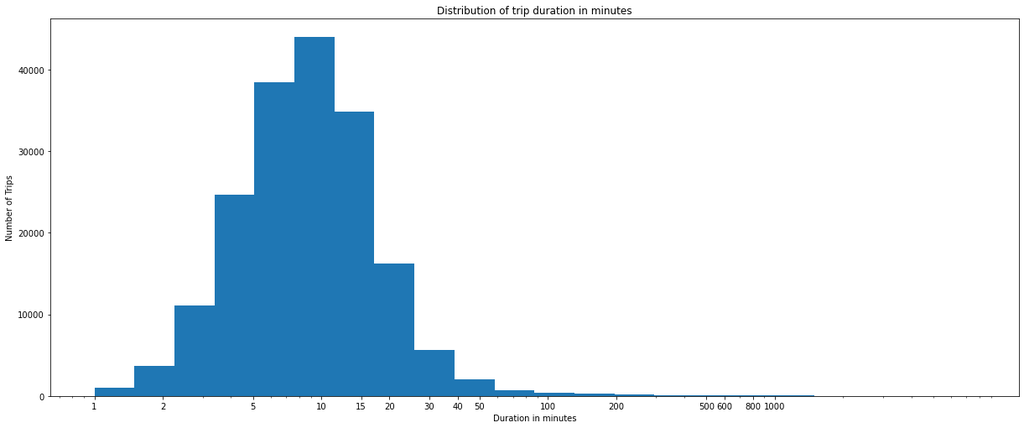

```python
log_bin_size = 0.15
log_bins = 15 ** np.arange(0.0, np.log10(bike_df1['duration_minutes'].max())+log_bin_size, log_bin_size)

plt.figure(figsize=[20.69, 8.27])
plt.hist(data = bike_df1, x = 'duration_minutes', bins=log_bins)
plt.title('Distribution of trip duration in minutes')
plt.xlabel('Duration in minutes')
plt.ylabel('Number of Trips')
plt.xscale('log')
tick_locs=[1,2,5,10,15,20,30,40,50,100,200,500,600,800,1000]
plt.xticks(tick_locs, tick_locs)
plt.show()
```

Using log-scale to plot the previous graph shows that the distribution has a peak between 8 and 15 which means that most of the bike trip takes between 5 and 15 minutes. From the analysis, the average bike trip duration was 12 minutes.

## Trip duration by gender

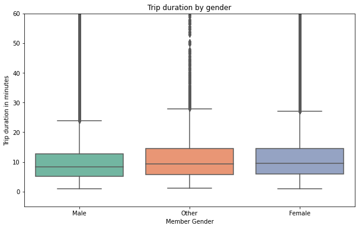

```python
plt.figure(figsize =[10,6])
sns.boxplot(x = 'member_gender', y='duration_minutes', data = bike_df1, palette='Set2')
plt.ylim(-5, 60)
plt.title('Trip duration by gender')
plt.xlabel('Member Gender')
plt.ylabel('Trip duration in minutes')
plt.show()
```

I reduced the y axis(duration_minutes) to 60 minutes so we can have a better view of the plot. the plot shows that the female and other gender have trip duration that is slightly higher than the male gender.

## Distribution of the users

Lets investigate the number of customers per user type using a bar chart.

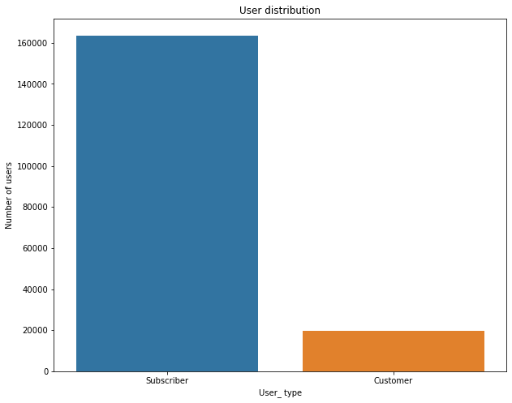

```python
# Lets plot a bar chart to show the user type
plt.figure(figsize=[10,8])
user_category = bike_df1['user_type'].value_counts().index
sns.countplot(data = bike_df1, x = 'user_type', order = user_category)
plt.title('User distribution')
plt.xlabel('User_ type')
plt.ylabel('Number of users')
plt.show()
```

From the above, it can be seen that majority of the users are subscribers (163,544) while the remaining 19,868 users are customers. This means that 89.2% of users are subscribers, they use the bikes more than the customers, and 10.8% of users are customers.

## Trip duration by user type

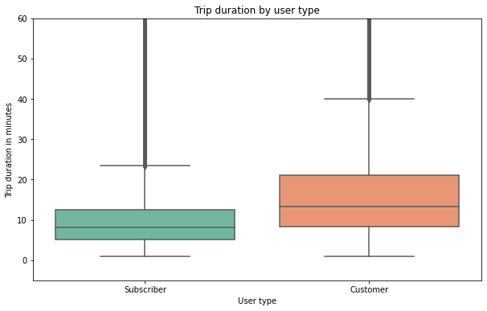

```python
plt.figure(figsize =[10,6])
sns.boxplot(x = 'user_type', y='duration_minutes', data = bike_df1, palette='Set2', order = ['Subscriber', 'Customer'])
plt.ylim(-5, 60)
plt.title('Trip duration by user type')
plt.xlabel('User type')
plt.ylabel('Trip duration in minutes')
plt.show()
```

From the above plot, we can see that the customers use the bike for longer duration than the subscribers.

The analysis shows that the subscribers use the bike ride for an average of 10 minutes while the customers use the bike ride for an average of 23 minutes.

## Distribution of user type by age group

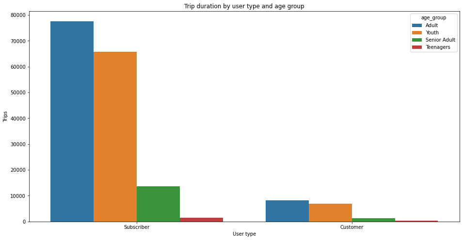

```python
plt.figure(figsize=[35,8])
plt.subplot(1, 2, 1)
age_group_chart = sns.countplot(data=bike_df1, x = 'user_type', hue ='age_group', order = bike_df1.user_type.value_counts().index)
age_group_chart.set_xlabel('User type')
age_group_chart.set_title('Trip duration by user type and age group')
age_group_chart.set_ylabel('Trips');
```

## Distribution of duration in seconds based on user type and gender

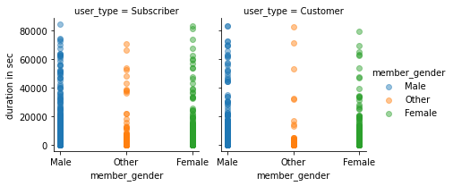

```python
plt.figure(figsize =[20, 15])
chart1 = sns.FacetGrid(data= bike_df1, col = 'user_type', col_order = ['Subscriber', 'Customer'], hue = 'member_gender')
chart1.map_dataframe(plt.scatter, 'member_gender', 'duration_sec', alpha = 0.46)
chart1.set_axis_labels('member_gender', 'duration in sec')
chart1.add_legend()
plt.show()
```

From the plot above, the Customer and subscriber user types seem to behave the same way in their trip duration, apart from the other gender which has a slight difference in user type and trip duration.

## Hourly rides per user type and age group

Finally, Lets look at the number of rides in each hour of the day for user types and age groups.

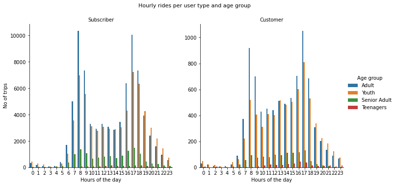

```python
hourly_age_group = sns.catplot(data = bike_df1, x = 'start_hour', col = 'user_type', col_order=['Subscriber', 'Customer'], hue = 'age_group', kind = 'count', sharey = False)
hourly_age_group.set_axis_labels("Hours of the day", " No of trips")
hourly_age_group._legend.set_title("Age group")
hourly_age_group.set_titles("{col_name}")
hourly_age_group.fig.suptitle('Hourly rides per user type and age group', y = 1.05, fontsize = 11);
```

From the chart above, we can see that the trip gets higher from 8am which is when workers need to get to work with adult age group having the highest number of trips, there is also a peak at 5pm which is when workers return from work. It can also be observed thatfor both type of users (customers and subscribers) the adult age group still takes the highest rides. it can also be noticed that from 7pm the numbe of rides for youths gets higher than other age group for both customers and subscribers.